# Machine Learning Project

Léonie Seels, Morgane Tinel, Clément Soulard

## Evolution of Renewable Energy Share Over Time and Across Countries

Renewable energy stands at the forefront of global efforts to create a sustainable and resilient future. Gaining a deep understanding of how renewable energy adoption has evolved across regions and decades is vital for policymakers, energy providers, and investors seeking to drive meaningful change.

This dataset captures the share of renewable energy from 1965 to the present, offering a comprehensive look at regional differences and long-term trends in the global energy transition. It contain 5603 point of data.

### Key Insights

- **Regional and Temporal Trends:** Explore which regions have accelerated their shift toward renewable energy, identify the most effective strategies, and highlight areas with the greatest potential for future investment.
- **Sustainable Development Goals:** Use these insights to support energy cost optimization and progress toward international sustainability targets.
- **Environmental Benefits:** Help shape strategies to minimize ecological footprints and promote a cleaner, greener planet.

The findings drawn from this dataset not only reveal how renewable energy usage has evolved over time but also serve as a guide for shaping the future of sustainable energy worldwide.

## Importation of module and Dataset

```python
 # Install all missing module :
import importlib
import subprocess
import sys

# Liste des modules dont tu as besoin
modules = ["numpy","pandas","matplotlib","seaborn","folium","geopandas","ipython","termcolor","scipy","kagglehub","jupyter","termcolor"]
for module in modules:
    try:
        importlib.import_module(module)
        print(f"{module} déjà installé")
    except ImportError:
        print(f"Installation de {module}...")
        subprocess.check_call([sys.executable, "-m", "pip", "install", module])
```

```
numpy déjà installé
pandas déjà installé
matplotlib déjà installé
seaborn déjà installé
folium déjà installé
geopandas déjà installé
Installation de ipython...
termcolor déjà installé
scipy déjà installé
kagglehub déjà installé
jupyter déjà installé
termcolor déjà installé
```

```python
 # Importation of all modules
import numpy as np
import pandas as pd
import datetime as dt
import matplotlib.pyplot as plt
import seaborn as sns
import folium
import geopandas as gpd
from IPython.display import HTML as html_print
from termcolor import colored
from scipy import stats
from termcolor import colored
from IPython.display import display
```

```python
 # Importation of the Dataset from Kaggle
import kagglehub
import os
import warnings
 # We will remove the warning to keep the notebook clean
warnings.filterwarnings('ignore')

 # Download latest version of the dataset
path = kagglehub.dataset_download("belayethossainds/renewable-energy-world-wide-19652022")

CSV_PATH = os.path.join(path, "01 renewable-share-energy.csv")

 # We place the Dataset in df
df = pd.read_csv(CSV_PATH)

 # We check that the data were correctly imported
print('DataFrame shape:', df.shape)
print('Columns:', df.columns.tolist())
print('\nFirst 5 rows:')
print(df.head())
```

```
DataFrame shape: (5603, 4)
Columns: ['Entity', 'Code', 'Year', 'Renewables (% equivalent primary energy)']

First 5 rows:
   Entity Code  Year  Renewables (% equivalent primary energy)
0  Africa  NaN  1965                                  5.747495
1  Africa  NaN  1966                                  6.122062
2  Africa  NaN  1967                                  6.325731
3  Africa  NaN  1968                                  7.005293
4  Africa  NaN  1969                                  7.956088
```

For our work we will study the Dataset about the share of renewable energy in the energy mix of different country and region. This dataset provides a broad view of the global adoption of renewable energy, covering country-level metrics over time on how nations are deploying clean energy technologies, increasing the share of renewables in their energy mix, and transforming their energy infrastructure for a sustainable future.

Here we can see that we have 4 columns in our dataset, the entity wich represent the country or the continent/region. The Code wich represent each country. The year and the share of renewable energy in the entity.

## Cleaning the Dataset

```python
# General knowledge about the dataset

# --- Section Title ---
print('Shape')
print(df.shape)

# --- Column Types ---
print('Types')
display(df.dtypes.to_frame('Data Type').style.set_caption("Data Types"))

# --- Head & Tail ---
print('Head & Tail')
display(df.head(5).style.set_caption("Head"))
display(df.tail(5).style.set_caption("Tail"))

# --- Missing Values ---
print('NA Values')
na_df = df.isnull().sum().reset_index()
na_df.columns = ['Column', 'Number of NA']
display(na_df.style.set_caption("Number of NA Values"))

# --- Quantiles ---
print('Quantiles')
quantiles_df = df.describe([0, 0.05, 0.50, 0.95, 0.99, 1]).T
display(quantiles_df.style.format("{:.2f}").set_caption("Quantiles"))

# --- Unique Entities ---
print('Unique Entities')
unique_entities = df['Entity'].unique()
print(unique_entities)
print(f"Total number of unique entities: {len(unique_entities)}")
```

```
Shape
(5603, 4)
Types
```

Data Types

|  | Data Type |
| --- | --- |
| Entity | object |
| Code | object |
| Year | int64 |
| Renewables (% equivalent primary energy) | float64 |

```
Head & Tail
```

Head

|  | Entity | Code | Year | Renewables (% equivalent primary energy) |
| --- | --- | --- | --- | --- |
| 0 | Africa | nan | 1965 | 5.747495 |
| 1 | Africa | nan | 1966 | 6.122062 |
| 2 | Africa | nan | 1967 | 6.325731 |
| 3 | Africa | nan | 1968 | 7.005293 |
| 4 | Africa | nan | 1969 | 7.956088 |

Tail

|  | Entity | Code | Year | Renewables (% equivalent primary energy) |
| --- | --- | --- | --- | --- |
| 5598 | World | OWID_WRL | 2017 | 11.355979 |
| 5599 | World | OWID_WRL | 2018 | 11.741059 |
| 5600 | World | OWID_WRL | 2019 | 12.237987 |
| 5601 | World | OWID_WRL | 2020 | 13.455194 |
| 5602 | World | OWID_WRL | 2021 | 13.470907 |

```
NA Values
```

Number of NA Values

|  | Column | Number of NA |
| --- | --- | --- |
| 0 | Entity | 0 |
| 1 | Code | 1311 |
| 2 | Year | 0 |
| 3 | Renewables (% equivalent primary energy) | 0 |

```
Quantiles
```

Quantiles

|  | count | mean | std | min | 0% | 5% | 50% | 95% | 99% | 100% | max |
| --- | --- | --- | --- | --- | --- | --- | --- | --- | --- | --- | --- |
| Year | 5603.00 | 1993.80 | 16.28 | 1965.00 | 1965.00 | 1968.00 | 1994.00 | 2019.00 | 2021.00 | 2021.00 | 2021.00 |
| Renewables (% equivalent primary energy) | 5603.00 | 10.74 | 12.92 | 0.00 | 0.00 | 0.00 | 6.52 | 34.56 | 67.37 | 86.87 | 86.87 |

```
Unique Entities
['Africa' 'Africa (BP)' 'Algeria' 'Argentina' 'Asia' 'Asia Pacific (BP)'
 'Australia' 'Austria' 'Azerbaijan' 'Bangladesh' 'Belarus' 'Belgium'
 'Brazil' 'Bulgaria' 'CIS (BP)' 'Canada' 'Central America (BP)' 'Chile'
 'China' 'Colombia' 'Croatia' 'Cyprus' 'Czechia' 'Denmark'
 'Eastern Africa (BP)' 'Ecuador' 'Egypt' 'Estonia' 'Europe' 'Europe (BP)'
 'European Union (27)' 'Finland' 'France' 'Germany' 'Greece'
 'High-income countries' 'Hong Kong' 'Hungary' 'Iceland' 'India'
 'Indonesia' 'Iran' 'Iraq' 'Ireland' 'Israel' 'Italy' 'Japan' 'Kazakhstan'
 'Kuwait' 'Latvia' 'Lithuania' 'Lower-middle-income countries'
 'Luxembourg' 'Malaysia' 'Mexico' 'Middle Africa (BP)' 'Middle East (BP)'
 'Morocco' 'Netherlands' 'New Zealand' 'Non-OECD (BP)' 'North America'
 'North America (BP)' 'North Macedonia' 'Norway' 'OECD (BP)' 'Oceania'
 'Oman' 'Pakistan' 'Peru' 'Philippines' 'Poland' 'Portugal' 'Qatar'
 'Romania' 'Russia' 'Saudi Arabia' 'Singapore' 'Slovakia' 'Slovenia'
 'South Africa' 'South America' 'South Korea'
 'South and Central America (BP)' 'Spain' 'Sri Lanka' 'Sweden'
 'Switzerland' 'Taiwan' 'Thailand' 'Trinidad and Tobago' 'Turkey'
 'Turkmenistan' 'USSR' 'Ukraine' 'United Arab Emirates' 'United Kingdom'
 'United States' 'Upper-middle-income countries' 'Uzbekistan' 'Venezuela'
 'Vietnam' 'Western Africa (BP)' 'World']
Total number of unique entities: 104
```

We can see that the Code column contributes a large number of missing (NA) values to the dataset, while providing little additional information, as it essentially duplicates the information contained in the Entity column.

Additionally, the data types of the columns are as follows: Entity is of type object, Year is int64, and the Share of Renewable column is in flot64.

```python
# We remove the column 'Code' because it doesn't add usefull information to our study

df = df.drop(columns=['Code'])
```

```python
df.head()
```

|  | Entity | Year | Renewables (% equivalent primary energy) |
| --- | --- | --- | --- |
| 0 | Africa | 1965 | 5.747495 |
| 1 | Africa | 1966 | 6.122062 |
| 2 | Africa | 1967 | 6.325731 |
| 3 | Africa | 1968 | 7.005293 |
| 4 | Africa | 1969 | 7.956088 |

```python
df.isnull().sum()
```

```
Entity                                      0
Year                                        0
Renewables (% equivalent primary energy)    0
dtype: int64
```

Now our Dataset is clean, we can continue our work

## Data pre-processing

```python
# 1. Remove exact duplicates
print("Initial shape:", df.shape)
df = df.drop_duplicates()
print("After removing duplicates:", df.shape)
```

```
Initial shape: (5603, 3)
After removing duplicates: (5603, 3)
```

```python
# 2. Basic consistency checks
# Ensure correct types and sorting
df['Year'] = df['Year'].astype(int)
df = df.sort_values(['Entity', 'Year'])
```

```python
# 3. Detect potential outliers per country (IQR method)
target_col = 'Renewables (% equivalent primary energy)'

# Sort by country + year so differences make sense
df_sorted = df.sort_values(['Entity', 'Year']).copy()

# Year-to-year change per country
df_sorted['diff'] = df_sorted.groupby('Entity')[target_col].diff()

# Define logical outliers:
#  - negative values
#  - values > 100
#  - huge jump (e.g. more than 20 percentage points in one year)
outliers = df_sorted[
    (df_sorted[target_col] < 0) |
    (df_sorted[target_col] > 100) |
    (df_sorted['diff'].abs() > 20)
]

print("Number of suspicious values:", len(outliers))
```

```
Number of suspicious values: 0
```

## 1st Exploration of the Dataset

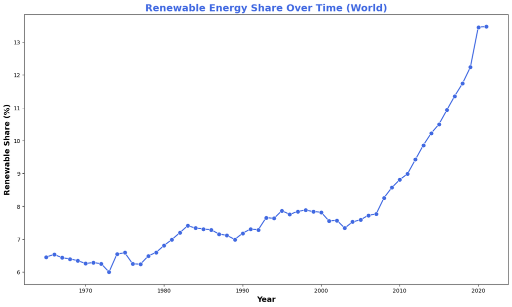

```python
plt.figure(figsize=(16,9))

# Filter for World only
df_world = df[df["Entity"] == "World"]

sns.lineplot(x='Year',y='Renewables (% equivalent primary energy)',data=df_world,color='royalblue',linewidth=2,marker='o',markersize=8)

plt.title('Renewable Energy Share Over Time (World)', fontsize=18, fontweight='bold', color='royalblue')
plt.xlabel('Year', fontsize=14, fontweight='bold')
plt.ylabel('Renewable Share (%)', fontsize=14, fontweight='bold')
plt.show()
```

In this first graph we can see that the global renewable energy share grow over time. It went from 6% in 1975 to 13% in 2020.

## Creation of the first models

We applied several models to forecast the future evolution of renewable energy share. k-Nearest Neighbors (k-NN) predicts values based on the closest historical points, which allows it to fit past data very closely but limits its ability to extrapolate beyond the observed range.

Decision Trees work by splitting the timeline into intervals and assigning a constant value to each segment based on the training data. This can closely follow historical trends, but predictions are piecewise constant and often fail to capture smooth, long-term growth.

Linear Regression fits a straight line through the data, providing a simple global trend. While it captures the overall direction of change, it cannot adapt to nonlinear accelerations or decelerations in the series, which may lead to under- or overestimations in the long term.

Support Vector Machines (SVM), using an RBF kernel, model a smooth nonlinear trend that extends the observed dynamics more plausibly into the future. Although SVM may not always outperform other models on standard metrics, it is generally the best at capturing long-term trends.

By comparing these models, we can see that methods excelling at interpolation, like k-NN and Decision Trees, struggle with true extrapolation scenarios, Linear Regression provides a simple but limited global trend, while SVM produces the most realistic long-term forecasts.

```python
# Create future years DataFrame
future_years = pd.DataFrame({
    "Year": range(world_df['Year'].max() + 1, 2051)
})
```

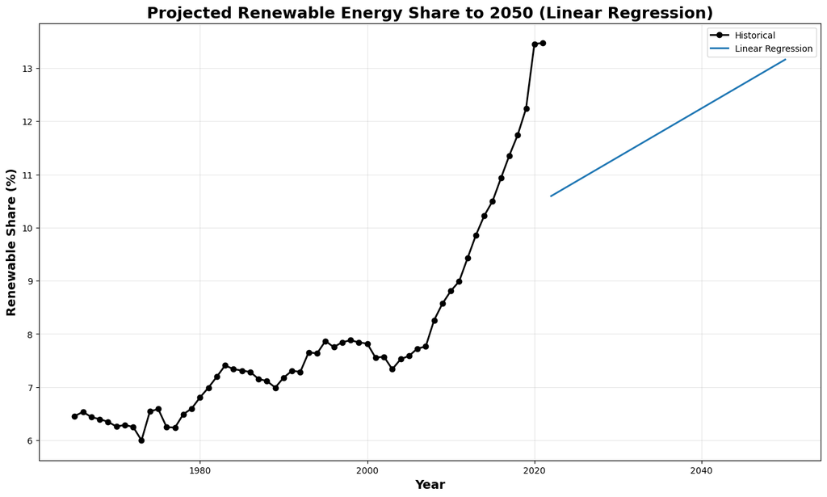

```python
from sklearn.linear_model import LinearRegression

# Filter dataset for "World"
world_df = df[df['Entity'] == 'World'].copy()
X = world_df[['Year']]
y = world_df['Renewables (% equivalent primary energy)']

# Define linear regression model
model = LinearRegression()

model.fit(X, y)
pred_future = model.predict(future_years[["Year"]])

plt.figure(figsize=(16, 9))
plt.plot(world_df['Year'], y, color='black', linewidth=2, marker='o', label='Historical')
plt.plot(future_years['Year'], pred_future, linewidth=2, label='Linear Regression')

plt.title('Projected Renewable Energy Share to 2050 (Linear Regression)', fontsize=18, fontweight='bold')
plt.xlabel('Year', fontsize=14, fontweight='bold')
plt.ylabel('Renewable Share (%)', fontsize=14, fontweight='bold')
plt.legend()
plt.grid(alpha=0.3)
plt.show()
```

We can see that our linear regression start at a lower point than the last year of our data. This is due to the variable growth of our data, as we can see the growth is low in the begening and high near 2015 (COP 21, Paris Accord). We can uplift our projection to predict futur value.

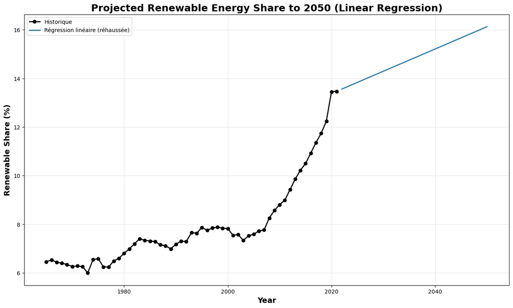

```python
# Linear regression
model = LinearRegression()
model.fit(X, y)

# row data
pred_future = model.predict(future_years[["Year"]])

# We calculate the difference between the last true value and our model
last_real_value = y.iloc[-1]
last_pred_value = model.predict([[world_df["Year"].iloc[-1]]])[0]

offset = last_real_value - last_pred_value

# We uplif all prediction
pred_future_adjusted = pred_future + offset

# Plot
plt.figure(figsize=(16, 9))
plt.plot(world_df['Year'], y, color='black', linewidth=2, marker='o', label='Historique')
plt.plot(future_years['Year'], pred_future_adjusted, linewidth=2, label='Régression linéaire (réhaussée)')

plt.title('Projected Renewable Energy Share to 2050 (Linear Regression)', fontsize=18, fontweight='bold')
plt.xlabel('Year', fontsize=14, fontweight='bold')
plt.ylabel('Renewable Share (%)', fontsize=14, fontweight='bold')
plt.legend()
plt.grid(alpha=0.3)
plt.show()
```

We can see with the linear regression that the predicted values follow an average growth trend based on our dataset. However, this may not be an appropriate model because the growth in recent years has been increasing very quickly.

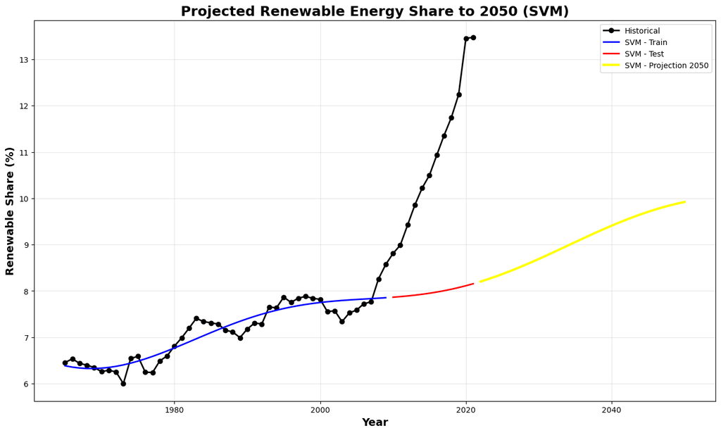

```python
# SVM
from sklearn.svm import SVR
from sklearn.model_selection import train_test_split
from sklearn.preprocessing import StandardScaler
from sklearn.pipeline import Pipeline

# Train/test split
X_train, X_test, y_train, y_test = train_test_split(
    X, y,
    test_size=0.2,
    shuffle=False, # chronological
    random_state=42
)

# SVM Model
svm_model = Pipeline([
    ("scaler", StandardScaler()),
    ("svr", SVR(kernel='rbf', C=100, gamma=0.1))
])

# Training
svm_model.fit(X_train, y_train)

# Predictions
pred_train = svm_model.predict(X_train)
pred_test = svm_model.predict(X_test)
pred_future_svm = svm_model.predict(future_years[["Year"]])

# Plot
plt.figure(figsize=(16, 9))

# Real data
plt.plot(world_df['Year'], y,
         color='black', linewidth=2, marker='o', label='Historical')

# SVM Results
# Training part (blue)
plt.plot(X_train['Year'], pred_train,
         color='blue', linewidth=2, label='SVM - Train')

# Test part (red)
plt.plot(X_test['Year'], pred_test,
         color='red', linewidth=2, label='SVM - Test')

# 2050 projection (yellow)
plt.plot(future_years['Year'], pred_future_svm,
         color='yellow', linewidth=3, label='SVM - Projection 2050')

plt.title('Projected Renewable Energy Share to 2050 (SVM)', fontsize=18, fontweight='bold')
plt.xlabel('Year', fontsize=14, fontweight='bold')
plt.ylabel('Renewable Share (%)', fontsize=14, fontweight='bold')
plt.legend()
plt.grid(alpha=0.3)
plt.show()
```

So we tried to shuffle the train test split to use random points of data to train the SVM.

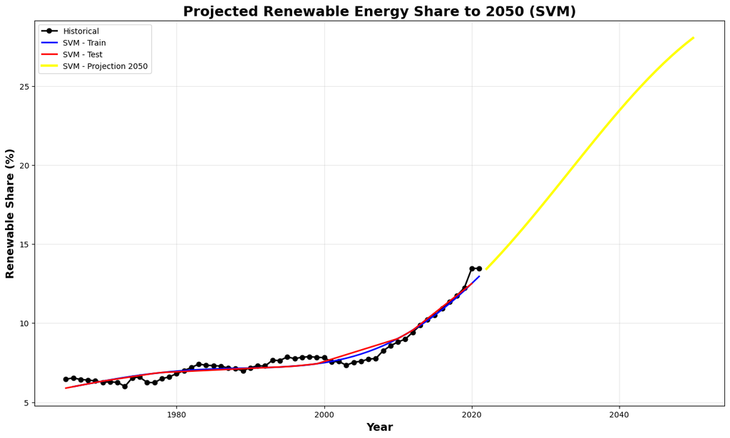

```python
# SVM

# Train/test split (random)
X_train, X_test, y_train, y_test = train_test_split(
    X, y,
    test_size=0.2,
    shuffle=True,  # random
    random_state=42
)

# SVM Model
svm_model = Pipeline([
    ("scaler", StandardScaler()),
    ("svr", SVR(kernel='rbf', C=100, gamma=0.1))
])

# Training
svm_model.fit(X_train, y_train)

# Predictions
pred_train = svm_model.predict(X_train)
pred_test = svm_model.predict(X_test)
pred_future_svm = svm_model.predict(future_years[["Year"]])

train_sorted = X_train.copy()
train_sorted["pred"] = pred_train
train_sorted = train_sorted.sort_values("Year")

test_sorted = X_test.copy()
test_sorted["pred"] = pred_test
test_sorted = test_sorted.sort_values("Year")

# Plot
plt.figure(figsize=(16, 9))

# Real data
plt.plot(world_df['Year'], y,
         color='black', linewidth=2, marker='o', label='Historical')

# Training part (blue)
plt.plot(train_sorted['Year'], train_sorted['pred'],
         color='blue', linewidth=2, label='SVM - Train')

# Test part (red)
plt.plot(test_sorted['Year'], test_sorted['pred'],
         color='red', linewidth=2, label='SVM - Test')

# 2050 projection (yellow)
plt.plot(future_years['Year'], pred_future_svm,
         color='yellow', linewidth=3, label='SVM - Projection 2050')

plt.title('Projected Renewable Energy Share to 2050 (SVM)', fontsize=18, fontweight='bold')
plt.xlabel('Year', fontsize=14, fontweight='bold')
plt.ylabel('Renewable Share (%)', fontsize=14, fontweight='bold')
plt.legend()
plt.grid(alpha=0.3)
plt.show()
```

Using this model, we apply an SVM to predict the future evolution of renewable energy share. The years are first normalized with StandardScaler to improve model performance, and an RBF-kernel SVR is then used to capture the nonlinear behavior in the data. The model is trained on the historical values (X, y) and applied to the future years stored in future_years. We then plot both the historical points and the SVM predictions to visualize the projection up to 2050 For future projection we use the train test split here with the shuffle on, and we can see that our prediction follow the recent growth increase..

From the SVM projection, we can see a smooth and quickly rising curve right after the most recent historical values. Since the RBF kernel captures nonlinear patterns, the model extends the recent rapid growth into the future, resulting in a trajectory that increases faster than a simple linear model. This suggests a continued and significant rise in renewable energy share in the coming decades, consistent with the strong acceleration observed in recent years. However, as with any nonlinear extrapolation, these values should be interpreted with caution because the model assumes that the recent rapid growth continues at a similar pace.

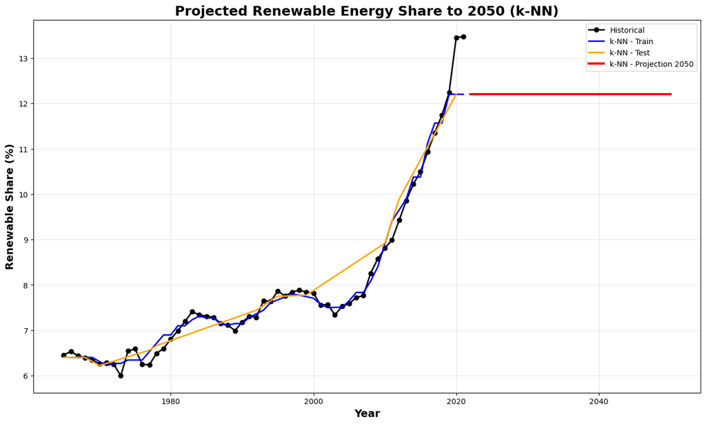

```python
# K-NN
from sklearn.neighbors import KNeighborsRegressor

# Train/test split (same structure as other models)
X_train, X_test, y_train, y_test = train_test_split(
    X, y,
    test_size=0.2,
    shuffle=True,
    random_state=42
)

# k-NN model
knn_model = KNeighborsRegressor(n_neighbors=4)

# training data
knn_model.fit(X_train, y_train)

# Predictions
pred_train_knn = knn_model.predict(X_train)
pred_test_knn  = knn_model.predict(X_test)

# Future prediction
pred_future_knn = knn_model.predict(future_years[["Year"]])

train_sorted = X_train.copy()
train_sorted["pred"] = pred_train_knn
train_sorted = train_sorted.sort_values("Year")
test_sorted = X_test.copy()
test_sorted["pred"] = pred_test_knn
test_sorted = test_sorted.sort_values("Year")

# Plot
plt.figure(figsize=(16, 9))

# Historical
plt.plot(world_df['Year'], y, color='black', linewidth=2, marker='o', label='Historical')

# Training part (blue)
plt.plot(train_sorted['Year'], train_sorted['pred'],
         color='blue', linewidth=2, label='k-NN - Train')

# Test part (orange)
plt.plot(test_sorted['Year'], test_sorted['pred'],
         color='orange', linewidth=2, label='k-NN - Test')

# 2050 projection (red)
plt.plot(future_years['Year'], pred_future_knn,
         color='red', linewidth=3, label='k-NN - Projection 2050')

plt.title('Projected Renewable Energy Share to 2050 (k-NN)', fontsize=18, fontweight='bold')
plt.xlabel('Year', fontsize=14, fontweight='bold')
plt.ylabel('Renewable Share (%)', fontsize=14, fontweight='bold')
plt.legend()
plt.grid(alpha=0.3)
plt.show()
```

We also tested a k-nearest neighbors (k-NN) model to predict the future evolution of renewable energy share. In this approach, the prediction for a given year is obtained by averaging the values of the closest years in the training data. While this can work for interpolation inside the observed period, it is not well adapted to our forecasting problem, where we need to extrapolate far beyond the last available year.

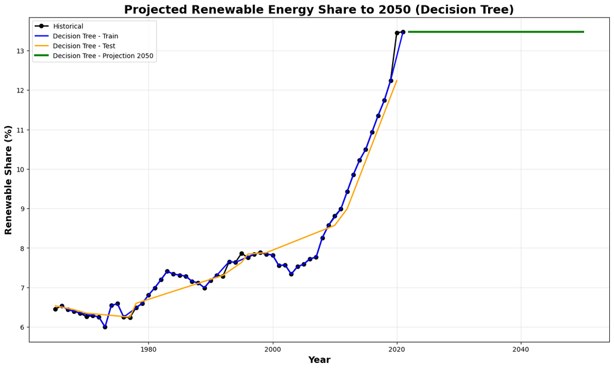

```python
# Decision tree
from sklearn.tree import DecisionTreeRegressor
from sklearn.model_selection import train_test_split

# Train/test split (random)
X_train, X_test, y_train, y_test = train_test_split(
    X, y,
    test_size=0.2,
    shuffle=True,
    random_state=42
)

# Define the Decision Tree model
tree_model = DecisionTreeRegressor(random_state=42)

# Train
tree_model.fit(X_train, y_train)

# Predictions
pred_train_tree = tree_model.predict(X_train)
pred_test_tree  = tree_model.predict(X_test)
pred_future_tree = tree_model.predict(future_years[["Year"]])

train_sorted = X_train.copy()
train_sorted["pred"] = pred_train_tree
train_sorted = train_sorted.sort_values("Year")
test_sorted = X_test.copy()
test_sorted["pred"] = pred_test_tree
test_sorted = test_sorted.sort_values("Year")

# Plot
plt.figure(figsize=(16, 9))

# Historical data
plt.plot(world_df['Year'], y,
         color='black', linewidth=2, marker='o', label='Historical')

# Training part  (blue)
plt.plot(train_sorted['Year'], train_sorted['pred'],
         color='blue', linewidth=2, label='Decision Tree - Train')

# Test part (orange)
plt.plot(test_sorted['Year'], test_sorted['pred'],
         color='orange', linewidth=2, label='Decision Tree - Test')

# 2050 projection (green)
plt.plot(future_years['Year'], pred_future_tree,
         color='green', linewidth=3, label='Decision Tree - Projection 2050')

plt.title('Projected Renewable Energy Share to 2050 (Decision Tree)', fontsize=18, fontweight='bold')
plt.xlabel('Year', fontsize=14, fontweight='bold')
plt.ylabel('Renewable Share (%)', fontsize=14, fontweight='bold')
plt.legend()
plt.grid(alpha=0.3)
plt.show()
```

We also applied a Decision Tree model to predict the future evolution of renewable energy share. This method works by splitting the timeline into intervals and assigning a constant value to each segment based on the training data. It can fit the historical data very closely, but the resulting prediction is piecewise constant rather than smooth.

For the future projection, we chose to use the SVM model. Unlike linear regression, k-NN, or decision trees, the SVM with an RBF kernel is able to capture the nonlinear acceleration observed in the most recent years of our dataset. This makes it better suited for modeling the strong upward trend in renewable energy share. While some models struggle to extrapolate beyond the historical period, the SVM provides a smooth and consistent curve that aligns well with the recent dynamics. For these reasons, it is the most appropriate model for forecasting the evolution of renewable energy up to 2050.

## Evaluation of models

In our analysis, we first evaluate each regression model using standard performance metrics such as MAE, RMSE and R². This allows us to compare how well the models fit the historical data and how accurately they can predict unseen values. Once the regression performance is assessed, we also explore a classification approach to categorize countries based on their renewable energy profiles. By converting the continuous renewable energy percentage into meaningful classes, we can use classification algorithms to identify groups of countries that share similar behaviors or levels of renewable adoption. This two-step approach gives us both a predictive understanding of future trends and an interpretative perspective on how different countries compare to one another.

```python
# Regression model evaluation with random split

from sklearn.metrics import mean_absolute_error, mean_squared_error, r2_score

# Keep only the "World" data
world_df = df[df["Entity"] == "World"].copy()

# X = year, y = renewable share
X = world_df[["Year"]].values
y = world_df["Renewables (% equivalent primary energy)"].values

print("Total number of points:", len(X))

# Random split 80/20
X_train, X_test, y_train, y_test = train_test_split(
    X, y, test_size=0.2, random_state=42
)

print("Train:", X_train.shape, " Test:", X_test.shape)


# Model definitions
models = {
    "Linear Regression": LinearRegression(),

    "Decision Tree": DecisionTreeRegressor(
        max_depth=4, random_state=42
    ),

    "k-NN": KNeighborsRegressor(n_neighbors=5),

    "SVM": Pipeline([
        ("scaler", StandardScaler()),
        ("svr", SVR(C=10, gamma=0.1, kernel="rbf"))
    ])
}

# Evaluation
results = []

for name, model in models.items():

    model.fit(X_train, y_train)
    y_pred = model.predict(X_test)

    mae = mean_absolute_error(y_test, y_pred)
    rmse = np.sqrt(mean_squared_error(y_test, y_pred))
    r2 = r2_score(y_test, y_pred)

    results.append([name, mae, rmse, r2])

    print(f"=== {name} ===")
    print(f"MAE  : {mae:.3f}")
    print(f"RMSE : {rmse:.3f}")
    print(f"R²   : {r2:.3f}\n")

# Summary table
results_df = pd.DataFrame(results, columns=["Model", "MAE", "RMSE", "R²"])
results_df = results_df.round(3)
display(results_df)
```

```
Total number of points: 57
Train: (45, 1)  Test: (12, 1)
=== Linear Regression ===
MAE  : 0.687
RMSE : 1.043
R²   : 0.717

=== Decision Tree ===
MAE  : 0.261
RMSE : 0.409
R²   : 0.956

=== k-NN ===
MAE  : 0.234
RMSE : 0.458
R²   : 0.945

=== SVM ===
MAE  : 0.383
RMSE : 0.691
R²   : 0.876
```

|  | Model | MAE | RMSE | R² |
| --- | --- | --- | --- | --- |
| 0 | Linear Regression | 0.687 | 1.043 | 0.717 |
| 1 | Decision Tree | 0.261 | 0.409 | 0.956 |
| 2 | k-NN | 0.234 | 0.458 | 0.945 |
| 3 | SVM | 0.383 | 0.691 | 0.876 |

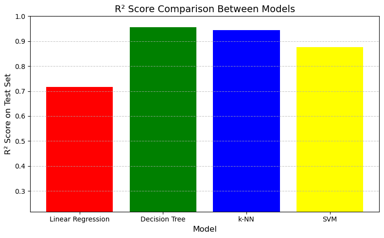

```python
# Visual comparison of the R² scores of the models

plt.figure(figsize=(8, 5))

# Colors
colors = ["red", "green", "blue", "yellow"]

plt.bar(results_df["Model"], results_df["R²"], color=colors)

plt.title("R² Score Comparison Between Models", fontsize=14)
plt.xlabel("Model", fontsize=12)
plt.ylabel("R² Score on Test Set", fontsize=12)

# Y-axis range for readability
plt.ylim(min(results_df["R²"]) - 0.5, 1.0)

plt.grid(axis="y", linestyle="--", alpha=0.7)
plt.tight_layout()
plt.show()
```

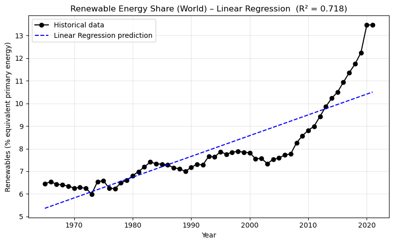

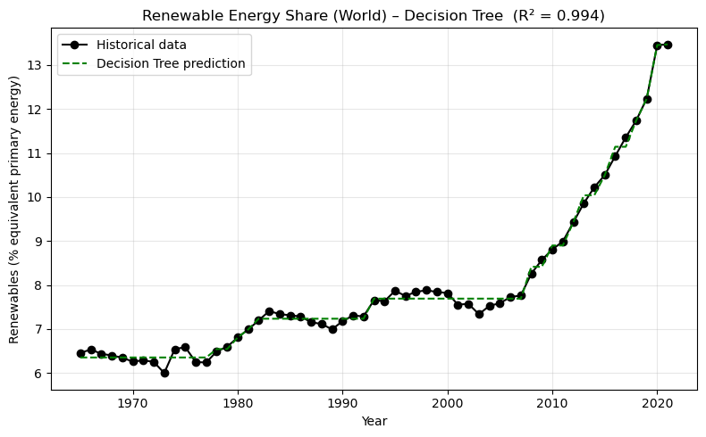

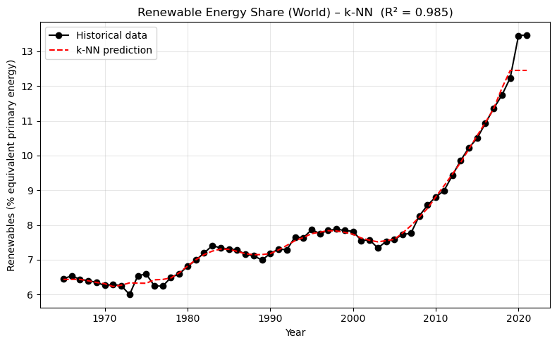

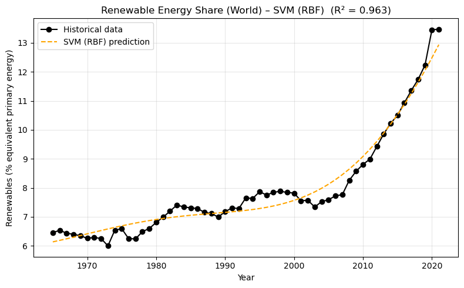

```python
from sklearn.metrics import r2_score

# Plot historical data and model predictions

# World dataset
df_clean = df.copy()

world_df = df_clean[df_clean["Entity"] == "World"].copy()
world_df = world_df.dropna(subset=["Year", "Renewables (% equivalent primary energy)"])
world_df = world_df.sort_values("Year")

years = world_df["Year"].values
X_full = years.reshape(-1, 1)
y_full = world_df["Renewables (% equivalent primary energy)"].values

# Models
models = {
    "Linear Regression": (LinearRegression(), "blue"),
    "Decision Tree": (DecisionTreeRegressor(max_depth=4, random_state=42), "green"),
    "k-NN": (KNeighborsRegressor(n_neighbors=5), "red"),
    "SVM (RBF)": (
        Pipeline([
            ("scaler", StandardScaler()),
            ("svr", SVR(C=100, gamma=0.1, kernel="rbf"))
        ]),
        "orange"
    )
}

# Fit on the full historical dataset and plot predictions
for name, (model, color) in models.items():
    model.fit(X_full, y_full)
    y_pred_full = model.predict(X_full)

    # Compute R² on full historical fit
    r2 = r2_score(y_full, y_pred_full)

    plt.figure(figsize=(8, 5))

    # Historical data
    plt.plot(
        years, y_full,
        marker="o", linestyle="-", label="Historical data", color="black"
    )

    # Model prediction
    plt.plot(
        years, y_pred_full,
        linestyle="--", label=f"{name} prediction", color=color
    )

    plt.title(f"Renewable Energy Share (World) – {name}  (R² = {r2:.3f})")
    plt.xlabel("Year")
    plt.ylabel("Renewables (% equivalent primary energy)")
    plt.grid(True, alpha=0.3)
    plt.legend()
    plt.tight_layout()
    plt.show()
```

Although k-NN and Decision Trees achieve better metrics on a random train_test_split as seen above, this is because they excel at interpolation: they memorize historical points very well and can easily predict years close to those already seen. However, when looking at projections up to 2050, we are in a true extrapolation scenario, where k-NN and Decision Trees completely fail (producing constant). In contrast, the SVM, thanks to its RBF kernel and smooth nonlinear trend, manages to extend the observed dynamics correctly and produces much more plausible curves. Thus, even if SVM is not always the best in terms of metrics, it is the model that captures long-term trends most accurately.

```python
# Pipelines and parameter grids

from sklearn.model_selection import GridSearchCV

pipelines = {
    "Linear Regression": Pipeline([
        ("scaler", StandardScaler()),
        ("model", LinearRegression())
    ]),
    "Decision Tree": Pipeline([
        ("model", DecisionTreeRegressor(random_state=42))
    ]),
    "k-NN": Pipeline([
        ("scaler", StandardScaler()),
        ("model", KNeighborsRegressor())
    ]),
    "SVM (RBF)": Pipeline([
        ("scaler", StandardScaler()),
        ("model", SVR(kernel="rbf"))
    ])
}

param_grids = {
    "Linear Regression": {
        "model__fit_intercept": [True, False]
    },
    "Decision Tree": {
        "model__max_depth": [2, 3, 4, 5, 6, None],
        "model__min_samples_leaf": [1, 2, 3, 5]
    },
    "k-NN": {
        "model__n_neighbors": [3, 5, 7, 9],
        "model__weights": ["uniform", "distance"]
    },
    "SVM (RBF)": {
        "model__C": [0.1, 1, 10, 100],
        "model__gamma": ["scale", 0.01, 0.1, 1.0],
        "model__epsilon": [0.01, 0.1, 0.5, 1.0]
    }
}

# GridSearchCV + test evaluation

results = []

for name, pipe in pipelines.items():
    print(f"\n===== GridSearch for {name} =====")

    grid = GridSearchCV(
        estimator=pipe,
        param_grid=param_grids[name],
        cv=5,
        scoring="r2",
        refit=True,
        verbose=1,
        n_jobs=-1
    )

    grid.fit(X_train, y_train)

    print("Best hyperparameters:", grid.best_params_)
    print("Best CV R²        :", round(grid.best_score_, 3))

    best_model = grid.best_estimator_

    # Final evaluation on the test set
    y_pred = best_model.predict(X_test)

    mae = mean_absolute_error(y_test, y_pred)
    rmse = np.sqrt(mean_squared_error(y_test, y_pred))
    r2 = r2_score(y_test, y_pred)

    results.append([name, mae, rmse, r2])

    print("Test performance:")
    print(f"  MAE  : {mae:.3f}")
    print(f"  RMSE : {rmse:.3f}")
    print(f"  R²   : {r2:.3f}")

# Summary table
results_df = pd.DataFrame(results, columns=["Model", "MAE", "RMSE", "R²"])
results_df = results_df.round(3)
print("\nFinal test summary")
display(results_df)
```

```
===== GridSearch for Linear Regression =====
Fitting 5 folds for each of 2 candidates, totalling 10 fits
Best hyperparameters: {'model__fit_intercept': True}
Best CV R²        : 0.347
Test performance:
  MAE  : 0.687
  RMSE : 1.043
  R²   : 0.717

===== GridSearch for Decision Tree =====
Fitting 5 folds for each of 24 candidates, totalling 120 fits
Best hyperparameters: {'model__max_depth': None, 'model__min_samples_leaf': 1}
Best CV R²        : 0.923
Test performance:
  MAE  : 0.216
  RMSE : 0.389
  R²   : 0.961

===== GridSearch for k-NN =====
Fitting 5 folds for each of 8 candidates, totalling 40 fits
Best hyperparameters: {'model__n_neighbors': 5, 'model__weights': 'distance'}
Best CV R²        : 0.95
Test performance:
  MAE  : 0.181
  RMSE : 0.338
  R²   : 0.970

===== GridSearch for SVM (RBF) =====
Fitting 5 folds for each of 64 candidates, totalling 320 fits
Best hyperparameters: {'model__C': 100, 'model__epsilon': 0.1, 'model__gamma': 'scale'}
Best CV R²        : 0.964
Test performance:
  MAE  : 0.238
  RMSE : 0.302
  R²   : 0.976

Final test summary
```

|  | Model | MAE | RMSE | R² |
| --- | --- | --- | --- | --- |
| 0 | Linear Regression | 0.687 | 1.043 | 0.717 |
| 1 | Decision Tree | 0.216 | 0.389 | 0.961 |
| 2 | k-NN | 0.181 | 0.338 | 0.970 |
| 3 | SVM (RBF) | 0.238 | 0.302 | 0.976 |

## Growth by income group

We will use a new dataset : World Bank Country and Lending Groups, this will give us the income group of the country in our dataset, we will then use these information to study the evolution of the pourcentage of renewable energy in the energy mix of different country by the income.

```python
# Import Kaggle dataset: World Bank Country and Lending Groups

# Download the dataset (Kaggle)
path_income = kagglehub.dataset_download("taniaj/world-bank-country-and-lending-groups")

INCOME_CSV = os.path.join(path_income, "worldbank_classification.csv")

# Load it
income_df = pd.read_csv(INCOME_CSV)

print("Income dataset shape:", income_df.shape)
print("Columns:", income_df.columns.tolist())
income_df.head()
```

```
Income dataset shape: (218, 7)
Columns: ['x', 'Economy', 'Code', 'Region', 'Income group', 'Lending category', 'Other']
```

|  | x | Economy | Code | Region | Income group | Lending category | Other |
| --- | --- | --- | --- | --- | --- | --- | --- |
| 0 | 1 | Afghanistan | AFG | South Asia | Low income | IDA | HIPC |
| 1 | 2 | Albania | ALB | Europe & Central Asia | Upper middle income | IBRD | NaN |
| 2 | 3 | Algeria | DZA | Middle East & North Africa | Upper middle income | IBRD | NaN |
| 3 | 4 | American Samoa | ASM | East Asia & Pacific | Upper middle income | NaN | NaN |
| 4 | 5 | Andorra | AND | Europe & Central Asia | High income | NaN | NaN |

```python
# cleaning
income_df_clean = income_df.rename(columns={
    "Economy": "Entity",
    "Income group": "IncomeGroup"
})[["Entity", "IncomeGroup"]]

print("Clean income_df:")
display(income_df_clean.head())

print("Unique income groups:")
print(income_df_clean["IncomeGroup"].unique())

# Merge with the first dataset
df_merged = df.merge(income_df_clean, on="Entity", how="inner")

# keeping only countries and remove 'Nan'
df_final = df_merged[[
    "Entity",
    "Year",
    "Renewables (% equivalent primary energy)",
    "IncomeGroup"
]].dropna().reset_index(drop=True)

print("Final clean dataset shape:", df_final.shape)
display(df_final.head())

print("Income groups in df_final:")
print(df_final["IncomeGroup"].unique())
```

```
Clean income_df:
```

|  | Entity | IncomeGroup |
| --- | --- | --- |
| 0 | Afghanistan | Low income |
| 1 | Albania | Upper middle income |
| 2 | Algeria | Upper middle income |
| 3 | American Samoa | Upper middle income |
| 4 | Andorra | High income |

```
Unique income groups:
['Low income' 'Upper middle income' 'High income' 'Lower middle income']
Final clean dataset shape: (3987, 4)
```

|  | Entity | Year | Renewables (% equivalent primary energy) | IncomeGroup |
| --- | --- | --- | --- | --- |
| 0 | Algeria | 1965 | 4.763068 | Upper middle income |
| 1 | Algeria | 1966 | 3.518747 | Upper middle income |
| 2 | Algeria | 1967 | 4.291954 | Upper middle income |
| 3 | Algeria | 1968 | 5.486195 | Upper middle income |
| 4 | Algeria | 1969 | 3.182764 | Upper middle income |

```
Income groups in df_final:
['Upper middle income' 'High income' 'Lower middle income']
```

This part of the code enriches our renewable-energy dataset by integrating the World Bank income-group information. We begin by cleaning the income table, renaming columns to match the structure of our main dataset and removing entries without a defined income group. Once this cleaning is done, we merge the two datasets using the country name as the key, keeping only the rows that correspond to real countries. We then extract the relevant columns—country, year, renewable share, and income group—while dropping any remaining missing values. The resulting dataframe provides a clean and consistent foundation for comparing renewable-energy trends across different income levels.

```python
# Countries by income groups

groups = df_final[["Entity", "IncomeGroup"]].drop_duplicates()

for group in groups["IncomeGroup"].unique():
    subset = groups[groups["IncomeGroup"] == group]["Entity"].sort_values().tolist()
    print(group)
    print(subset)
    print()
```

[output not shown]

```python
# Mean value by years for every income group
income_mean = (
    df_final
    .groupby(["IncomeGroup", "Year"])["Renewables (% equivalent primary energy)"]
    .mean()
    .reset_index()
    .sort_values(["IncomeGroup", "Year"]))

print("Average renewable share by Income Group (all years):")
display(income_mean)
```

```
Average renewable share by Income Group (all years):
```

|  | IncomeGroup | Year | Renewables (% equivalent primary energy) |
| --- | --- | --- | --- |
| 0 | High income | 1965 | 11.082284 |
| 1 | High income | 1966 | 11.258799 |
| 2 | High income | 1967 | 11.054687 |
| 3 | High income | 1968 | 10.662791 |
| 4 | High income | 1969 | 10.385446 |
| ... | ... | ... | ... |
| 166 | Upper middle income | 2017 | 11.435902 |
| 167 | Upper middle income | 2018 | 12.332862 |
| 168 | Upper middle income | 2019 | 12.359255 |
| 169 | Upper middle income | 2020 | 13.585406 |
| 170 | Upper middle income | 2021 | 13.404006 |

171 rows × 3 columns

In this section, the code computes the yearly average renewable-energy share for each income group. We group the cleaned dataset by both year and income category, and calculate the mean renewable share across all countries belonging to that group. This step smooths out country-specific variations and produces representative trajectories for high-, upper-middle-, and lower-middle-income groups. By sorting the results by group and year, we obtain clear time-series profiles that can be directly plotted or used as input for machine-learning models.

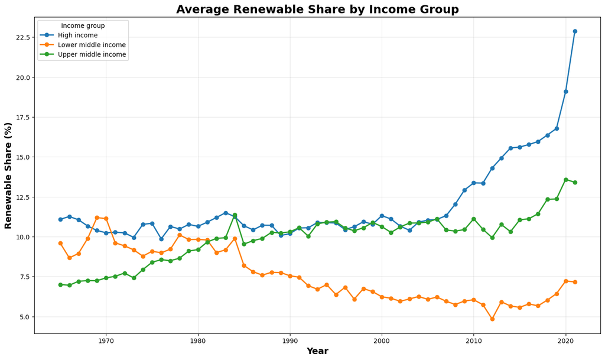

```python
# plot
plt.figure(figsize=(16, 9))

for group in income_mean["IncomeGroup"].unique():
    subset = income_mean[income_mean["IncomeGroup"] == group]
    plt.plot(
        subset["Year"],
        subset["Renewables (% equivalent primary energy)"],
        linewidth=2,
        marker="o",
        label=group
    )

plt.title("Average Renewable Share by Income Group", fontsize=18, fontweight="bold")
plt.xlabel("Year", fontsize=14, fontweight="bold")
plt.ylabel("Renewable Share (%)", fontsize=14, fontweight="bold")
plt.grid(alpha=0.3)
plt.legend(title="Income group")
plt.show()
```

This graph show how renewable-energy usage evolves across income groups. For each group, the code extracts its averaged time series and draws it on the graph. This first graph already reveals important differences: high-income countries generally show higher renewable growth in recent years, while lower-income categories evolve more slowly. This visualization provides a direct, intuitive overview of the disparity between income groups.

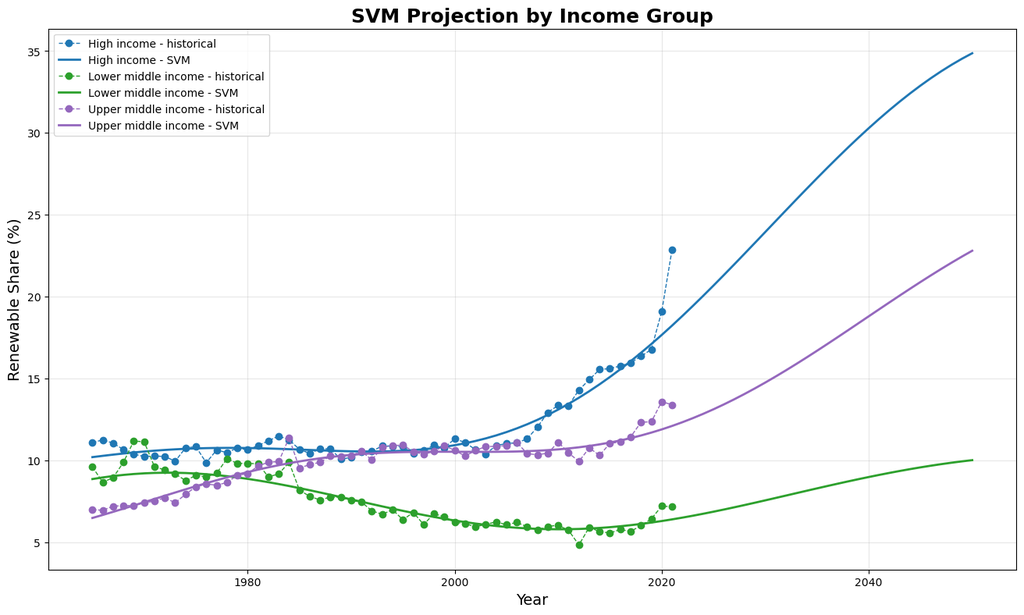

```python
# Years of projection
future_years = pd.DataFrame({"Year": np.arange(df_final["Year"].min(), 2051)})

# Define consistent colors for each income group
group_colors = {
    "High income": "tab:blue",
    "Upper middle income": "tab:purple",
    "Lower middle income": "tab:green",
    "Low income": "tab:red"
}

# Plot
plt.figure(figsize=(16, 9))

for group in sorted(income_mean["IncomeGroup"].unique()):
    sub = income_mean[income_mean["IncomeGroup"] == group].copy()

    X = sub[["Year"]].values
    y = sub["Renewables (% equivalent primary energy)"].values

    # train test split
    X_train, X_test, y_train, y_test = train_test_split(
        X, y,
        test_size=0.2,
        shuffle=True,  # random
        random_state=42
    )

    # SVM
    svm_model = Pipeline([
        ("scaler", StandardScaler()),
        ("svr", SVR(kernel="rbf", C=200, gamma=0.1))
    ])
    svm_model.fit(X_train, y_train)

    # Projection for historic and future values
    y_svm = svm_model.predict(future_years[["Year"]].values)

    # color
    color = group_colors.get(group, "black")

    # Mean data for historic values
    plt.plot(
        sub["Year"],
        sub["Renewables (% equivalent primary energy)"],
        linestyle="--",
        marker="o",
        linewidth=1,
        color=color,
        label=f"{group} - historical"
    )

    # plot
    plt.plot(
        future_years["Year"],
        y_svm,
        linewidth=2,
        color=color,
        label=f"{group} - SVM"
    )

plt.title("SVM Projection by Income Group", fontsize=18, fontweight="bold")
plt.xlabel("Year", fontsize=14)
plt.ylabel("Renewable Share (%)", fontsize=14)
plt.grid(alpha=0.3)
plt.legend()
plt.show()
```

We applied the SVM model to each income group to predict future renewable-energy trends. For every group, we treat the year as the input feature and the averaged renewable share as the target. A randomized 80/20 train–test split ensures that the model sees a balanced mix of years during training. The SVR is then fitted, and the model is used to generate predictions from the earliest year in the dataset up to 2050.

The resulting graph highlights clear structural differences between income groups. High-income countries start with the highest renewable share and, according to the SVM, are projected to accelerate strongly in the coming decades, reaching the highest levels by 2050. Upper-middle-income countries show a more gradual but steady increase, with the model suggesting a significant catch-up compared with their initial values. By contrast, lower-middle-income economies display a flatter trajectory: their historical averages are lower and the SVM projection remains more modest, indicating slower growth in the renewable share if current patterns persist. Overall, this analysis suggests that income level is closely linked to both the current penetration of renewables and the expected future speed of the energy transition.

High-income countries show the steepest projected increase, which can be explained by their greater investment capability, faster adoption of new technologies, and stronger policy commitments toward decarbonization. These countries already started from higher renewable-energy levels and have the financial means to accelerate this transition further. Upper-middle-income economies exhibit a moderate upward trend, reflecting improving infrastructure but more limited resources compared to high-income regions. Meanwhile, lower-middle-income countries show a flatter projection: their slower growth is typically linked to structural barriers such as restricted capital, lower electrification rates, and competing development priorities. Overall, the SVM projection reinforces the idea that economic development strongly influences a country’s ability to scale up renewable energy in the coming decades.

## Conclusion

This project combined data cleaning, exploratory analysis, and several machine-learning models to investigate global renewable-energy trends and produce projections to 2050. After constructing a clean dataset and enriching it with World Bank income-group information, we generated historical averages and trained models such as linear regression, k-NN, decision trees, and SVMs. Among these, the RBF-kernel SVM consistently provided the most realistic long-term trajectories, successfully capturing the non-linear growth patterns visible in the data. By applying this model separately to each income group, we highlighted strong structural disparities: high-income countries show rapid and accelerating renewable-energy adoption, upper-middle-income countries progress more steadily, while lower-middle-income groups remain far behind.

These projections, however, also reveal a concerning mismatch with global climate objectives. Even under optimistic assumptions, the modeled growth of renewables especially in middle-income regions remains insufficient to meet the levels required to keep global warming below 2°C, let alone 1.5°C. High-income countries alone cannot compensate for the slower transition elsewhere, and the aggregated global trend implied by our models corresponds to a warming pathway above 2°C. This highlights a fundamental challenge: achieving climate targets will require not only continued acceleration in developed economies, but also significant international support, investment, and technological diffusion to enable faster renewable expansion in emerging and developing countries.

Overall, the project demonstrates the value of combining statistical preprocessing with machine-learning models to explore energy-transition pathways, while also making clear that current trends even when optimistically extrapolated fall short of what is needed to stabilize the climate.